# Insights Derived from the WeRateDogs Wrangled Data

## Introduction

WeRateDogs is a very famous twitter account with over 4 million followers, that has gained wide media coverage over the years for their humorous contents about dogs. Created in 2015, it started rating dogs and have continued to do so till date. Using a metric score of 10, most dogs have been rated with numerator values higher than 10 by WeRateDogs for the simple reason that they are good dogs, [Brent](https://knowyourmeme.com/memes/theyre-good-dogs-brent)!(click to find out about this inside joke!)

I completed a project on wrangling data from the twitter archive of WeRateDogs. The dataset contained basic tweet data for over 5000 tweets but only those with ratings were used. Additional data was also sourced programmatically to supplement this data by querying Twitter's API as well as downloading programatically, a dataset about the top 3 predictions of dog breeds by an algorithm using images contained in the twitter archive. The gathered 3 datasets were then properly assessed, cleaned and then merged into one dataset

In the following sections, I will discuss all the insights that were generated from the wrangled data with visualizations to aid comprehension.

Three major questions were the basis for this data analyses:

1. Which dog stage has the highest ratings?
2. Which dog stage has the most likes and retweets?
3. What breed of dogs were mostly predicted to be true with the highest confidence?

### 1. Dog Stage with the highest ratings

From the analysis conducted, it was discovered that puppo had the highest average ratings amongst the dog stages with a value of ~12, followed closely by floofer. The dog stage with the least average ratings was pupper with a rating of 10.6 (see figure below).

However, because of their very close values, it was suggested that there may be no significant statistical difference amongst them in terms of ratings.

I thought that it would help to see if the ratings awarded by @WeRateDogs were ratings that resonated with the people (the twitter audience).To find out, the dog stage with the most likes as well as retweets were analysed next.

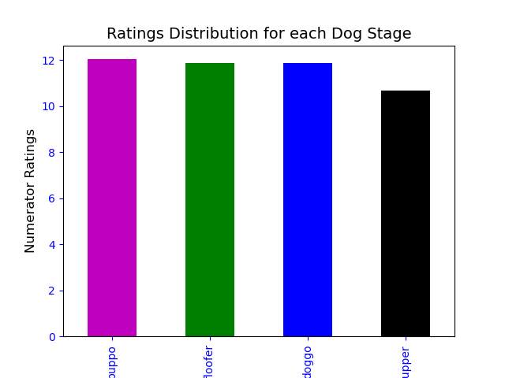

### 2. Dog Stage with the Most Likes & Retweets

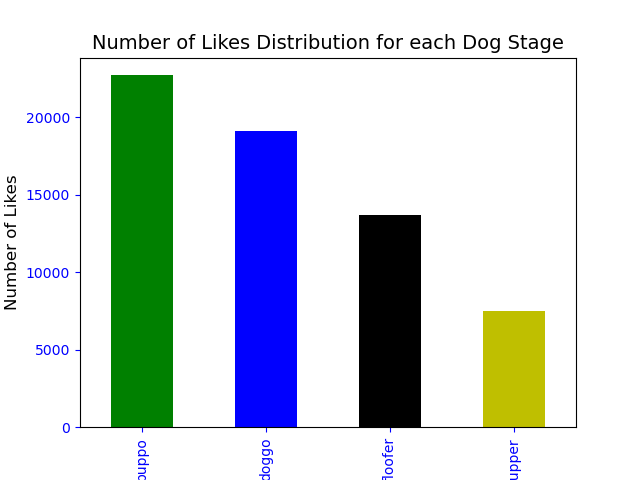

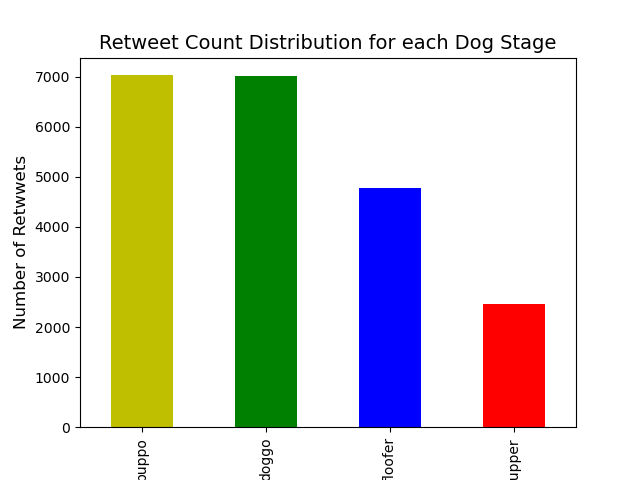

The figures above are the results of the analyses carried out. Puppo appeared to be popular amongst the people with an average of over 22000 likes and 7000 retweets. However, the doggos displaced the floofers as the second most retweeted and second most liked category of dog stage. The puppers retained their position as been the least liked and least retweeted about dog stage with almost 2500 retweets and 7485 likes. A 10/10 bad day for the puppers, I'd say!

In a general sense, it can be said that the ratings distribution almost conforms to the opinions of the @WeRateDogs twitter community.

It is important to note however that these insights might not be totally accurate and might even contain some level of bias because the data used contained so many missing values in the dog stage that even imputing the mean value of available dog stages would have still been skewed in some form. For context, there were 1668 missing dog stage values out of 1974 records! Maybe there is some hope for the puppers afterall!

### 3. Proportion of Dog Breeds Mostly Predicted Correctly

Data obtained from a neural network algorithm and was used to predict dog breeds from @WeRateDogs twitter archive was gathered and analysed to get the top ten most popular dog breeds that were predicted correctly by the algorithm. The result is visually illustrated in the donut pie chart below:

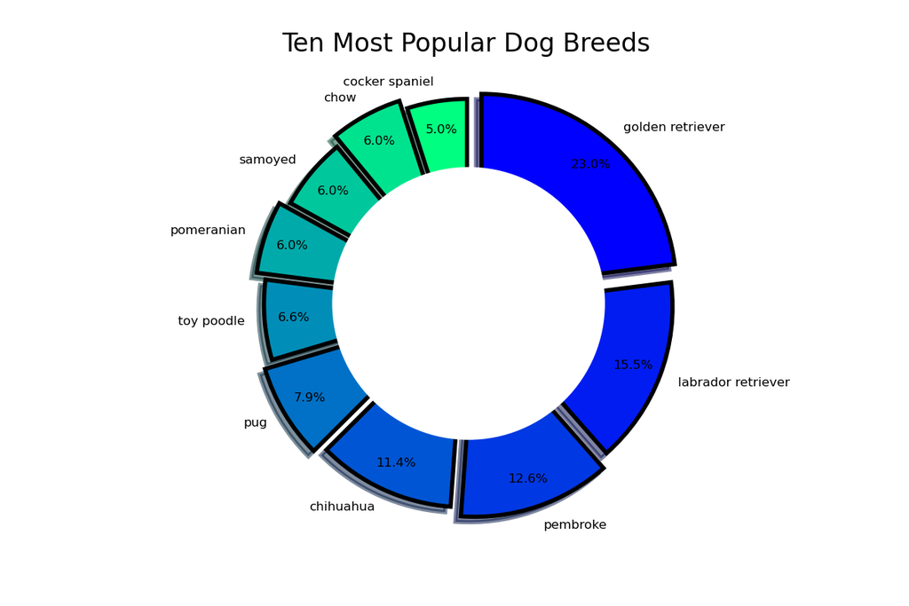

The data reveals that the golden retriever is the number one dog breed that was correctly predicted by the algorithm used, with 111 dogs, closely followed by the labrador retriever, the pembroke and the chihuahua. On the flip side, the cocker spaniel is the 10th most popular kind with 24 dogs, closely followed by the chow, the samoyed and the pomeranian.

### Conclusion

I really had fun carrying out these analyses using the WeRateDogs twitter archive as well as making use of the additional data sourced. As usual, I'll close with this:

**My questions for you:**

- What insights were you able to get from this?
- What kinds of analyses do we need to perform to confirm or disprove your thoughts or assumptions concerning WeRateDogs?

**My gold nuggets:**

- Follow @dogrates on twitter and if you have a pupper, please dress him up nicely and put him up for submission to help scale the ratings for our poor puppers. I mean, just look at these cuties!

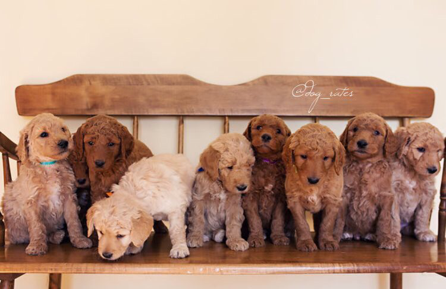

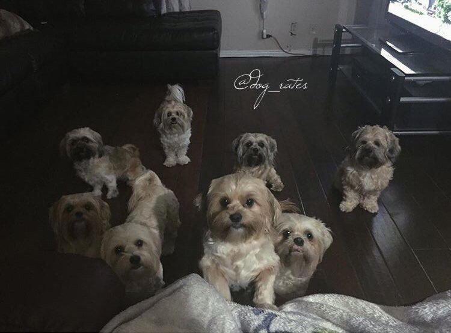